# Interest Income forecast of XYZ Bank

ABSTRACT.............................................................................................

INTRODUCTION...................................................................................

LITERATURE REVIEW……....................................................................…

OBJECTIVES & PRINCIPLES...................................................................

ANALYSIS & DESIGN............................................................................

SUMMARY OF ANALYSIS………...……………….........……………………………..

RECOMONDATONS ………………………………............................................

CONCLUSION.......................................................................................

REFERENCES........................................................................................

APPENDIX…...........................................................................................

### Abstract

The net interest income of some banks is more sensitive to changes in interest rates than others. This can vary according to several factors, such as the type of assets and liabilities that are held as well as if those assets and liabilities have fixed rates or variable rates. Banks with variable rate assets and liabilities will be more sensitive to changes in interest rates than those with fixed rate assets and liabilities. Banks with liabilities that reprice more often or quicker than their assets will be more negatively affected by interest rate changes.

Net interest income is the difference between the revenue that is generated from a bank's assets and the expenses associated with paying out its liabilities. A typical bank's assets consist of all forms of personal and commercial loans, mortgages and securities. The liabilities are the customer deposits. The excess revenue that is generated from the interest earned on assets over the interest paid out on deposits is the net interest income.

### Introduction

The type of assets earning interest for the bank can vary greatly from mortgages to auto loans, personal loans and commercial real estate loans. This will ultimately affect the interest rate a bank earns on its assets and the resulting net interest income after subtracting interest paid to depositors. Moreover, loans of the same type can carry fixed rates or variables rates. This is most often seen with mortgages as banks offer fixed rate and adjustable rate mortgages. Quality of the loan portfolio is also a factor affecting net interest income as circumstances like a deteriorating economy and job losses can cause borrowers to miss payments on their loans and lower the bank's net interest income as a result.

Weak net interest income is of particular concern for the long term viability of XYZ bank. The heart of bank business model is mostly lending to local businesses and households, which makes net interest income the largest source of core operating revenue. According to many commentators, including XYZ bankers, it has been difficult to earn an adequate spread on loans in the current recovery because of the low interest rates and flat yield curve resulting from the Federal Reserve’s accommodative monetary policy. In addition, bankers say weak lending opportunities have contributed to reduced interest income. Thus, after more than four years of economic recovery, it is important to know whether low levels of net interest income is “normal” after accounting for factors such as low interest rates, reduced lending, and other cyclical factors, or is it cause for alarm due to other factors that are unlikely to be reversed when the economy improves.

This article examines the historical behavior of net interest income for XYZ bank, focusing on how it compares in the current recovery to four previous recoveries starting in the mid-1970s. The data show low interest rates, a flat yield curve, and a decline in lending are important reasons why net interest income still has not recovered. In fact, compared to the recoveries from the relatively severe 1973-75 and 1981-82 recessions, net interest income is somewhat stronger this far into the recovery. Thus, as monetary policy normalizes and the economy recovers, XYZ bank net interest income should be expected to rise toward pre-recession levels.

In this paper, conducting statistical analysis, Modeling, forecasting and reviewing the recent performance of XYZ bank and performance of model and focusing on net interest income.

Composition of assets and liabilities: Net interest income is affected not only by the maturity and repricing structure of assets and liabilities, but also by their composition. The interest rate on bank loans generally is higher than on marketable securities because loans tend to be riskier. In addition, loans are costlier investment because of the information requirements to make the loan and high monitoring costs once the loan is made. Moreover, some types of loans, such as commercial land development loans, are riskier and costlier to make and monitor than other types of loans. As a result, net interest income should increase with balance sheet measures such as the ratio of loans to total assets and share of loans to real estate developers.

On the liability side of the balance sheet, nonmaturity deposits tend to have the lowest interest expenses of all of a bank’s liabilities. One reason is transaction deposits, which are a large share of nonmaturity deposits, provide transactions services that banks do not explicitly price. Instead, the deposit rates that banks pay are lower than comparable deposits that do not provide transactions services. In addition, a provision of the Banking Act of 1933 prohibited banks from paying interest on demand deposits, which has primarily affected business checking accounts since the mid-1980s, when banks were allowed to pay interest on other transaction deposits. While that provision was repealed as of July 2011 by the 2010 Dodd-Frank Wall Street Reform and Consumer Protection Act, few if any banks pay interest on business checking accounts. In addition, as previously noted, nonmaturity deposit rates tend to be sticky when short-term interest rates change, especially in markets where banks face little local competition. The low cost of nonmaturity deposits has a particularly large effect on net interest income because they represent such a large share of bank liabilities.

For example, in the third quarter of 2013, nonmaturity deposits accounted for 64 percent of XYZ bank liabilities.

### Objectives & Principles

This case study is designed to explore fitting of ARIMA models using R on bank 'Net Interest Income' historical data, and generate forecast for future Quuarters. Choosing ARIMA models is popular and flexible class of forecasting models, and provide a basic foundation on which extremely complex models can also be built. For the data analysis part, we shortlisted analyzing the historical behavior of net interest income for XYZ bank comparing from the mid-1970

### Literature Review

3.2 Balance Sheet Components of the Bank A balance sheet (or statement of condition, statement of financial position) is a financial report that shows the value of a company's assets, liabilities, and owner's equity on a specific date, usually at the end of an accounting period, such as a quarter or a year. An asset is anything that can be sold for value. A liability is an obligation that must eventually be paid, and, hence, it is a claim on assets. The owner's equity in a bank is often referred to as bank capital, which is what is left when all assets have been sold and all liabilities have been paid.

3.3 Example of Net Interest Income If a bank has a loan portfolio of 1 billion dollars earning 5 percent interest, the bank's interest revenue will be 50 million dollars. On the liability side, if the bank has outstanding customer deposits of 1.2 billion dollars earning 2 percent interest, then interest expense will be 24 million dollars. With 50 million dollar in interest revenue and subtracting 24 million dollar in interest expense, the bank will be generating $$26 million in net interest income.

3.4 Conclusion The analysis of bank dataset helps to discover patterns and Income that helps to estimate the revenue of a bank in credit risk sector.

### Analysis & Design

Below is the step by step procedure that helps to forecast the Interest income of XYZ Bank for 9 Quarters.

#### 1. Checking the summary of the data to understand the behavioral aspects.

```r
setwd("C:/Users/LOCALUSER/Desktop/material/stat/project/PIIN Models")
### Packages that need to be installed for Time series forecasting
install.packages("forecast", repos="http://cran.us.r-project.org")

library(forecast)
```

```r
library(tseries)
```

```r
library(fpp)
```

```r
#### Import the data to R environment
IIN2<-read.csv("C:/Users/LOCALUSER/Desktop/material/stat/project/PIIN Models/PIN2.csv" )
### Analyse the basic statistics of imported data
summary(IIN2)
```

```
      DATE       PINTI17Q1
 1947:Q1:  1   Min.   :   8.8
 1947:Q2:  1   1st Qu.:  44.6
 1947:Q3:  1   Median : 440.6
 1947:Q4:  1   Mean   : 526.2
 1948:Q1:  1   3rd Qu.: 968.5
 1948:Q2:  1   Max.   :1382.3
 (Other):274
```

Interpretation: The data is ranging vast as the minimum, mean and maximum values of the time series (IIN) is varying large.

#### 2.Checking the graphical representation of the data to understand the behavior of time series data.

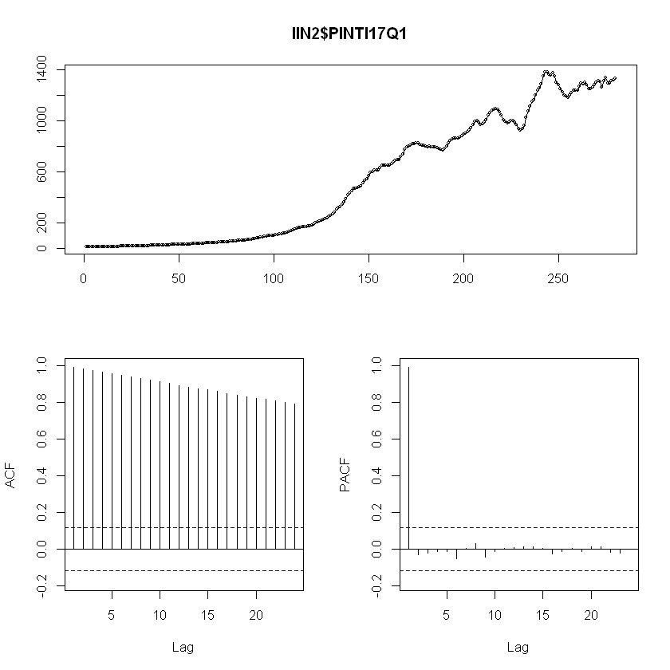

```r
tsdisplay(IIN2$PINTI17Q1)
```

Interpretation: The 1st chart says that the series is ranging from almost 8 million dollars to 1400 million dollars. And other 2 charts explain that there is no seasonal effect in the model.

#### 3. Box cox transformation has been applied to the Interest Income data and below charts are generated.

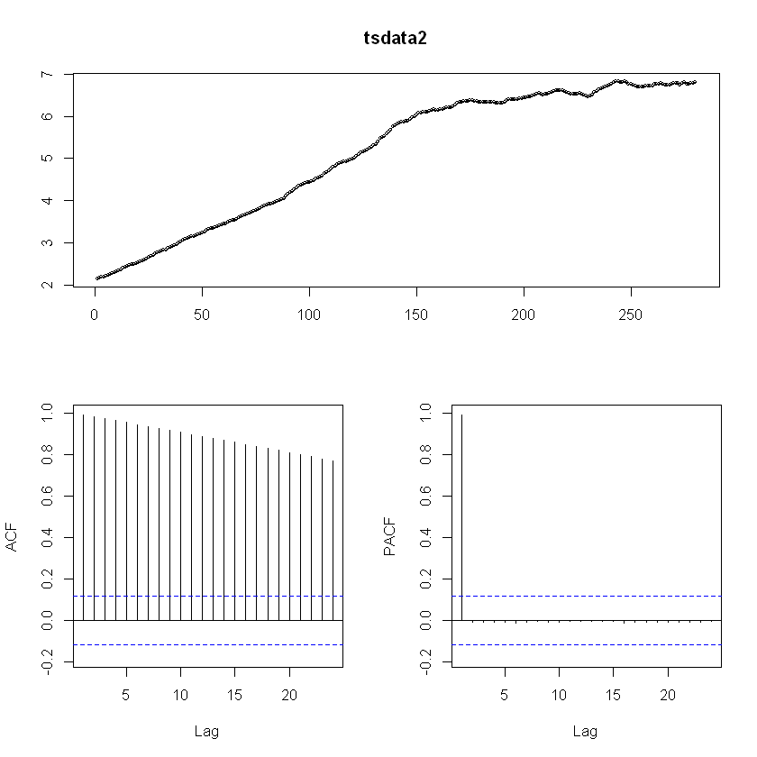

```r
lambda = BoxCox.lambda(IIN2$PINTI17Q1)
tsdata2 = BoxCox(IIN2$PINTI17Q1, lambda=lambda)
tsdisplay(tsdata2)
```

Interpretation: The smoothening of data has been done, but due to presence of trend component The Box cox transformation that has been applied and is not helping the time series to convert into stationary. This can be interpreted by looking the continuous growth in the first chart.

#### 4. Checking seasonal and Month plots

```r
IIN<-IIN2[100:272,]
seasonplot(IIN$PINTI17Q1)
```

[output not shown]

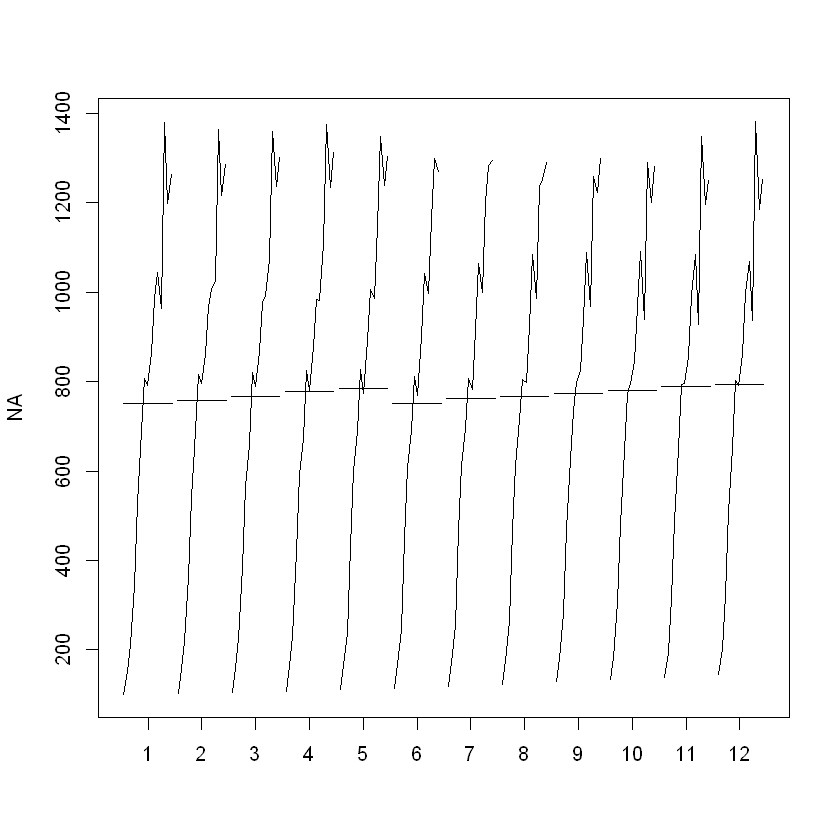

```r
monthplot(IIN$PINTI17Q1)
```

Interpretation:As Interest Income data do not depend on season, so we can’t execute seasonal plot. The below month plot also reavels the same as above statement. If the series expose to some seasonality, the Interest Income series of each month would be different.

```r
library("TTR")
```

```r
trend_IIN= ma(IIN2[,2], order = 4, centre = T)
```

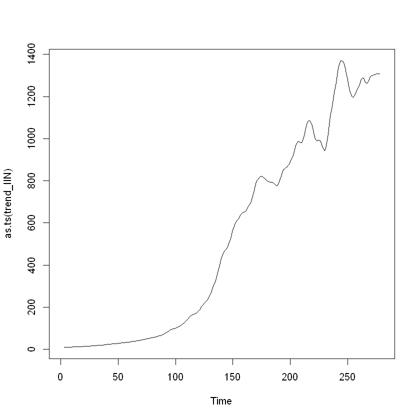

```r
plot(as.ts(trend_IIN))
lines(trend_IIN)
```

```r
write.csv(trend_IIN, "trend_IIN_python.csv")
```

```r
trend_IIN2<-as.data.frame(trend_IIN)
trend_IIN3<-trend_IIN2[3:278,]
IIN_f<-IIN2[3:278,]
```

#### 5. Detrending the Interest Income Component to achieve stationarity

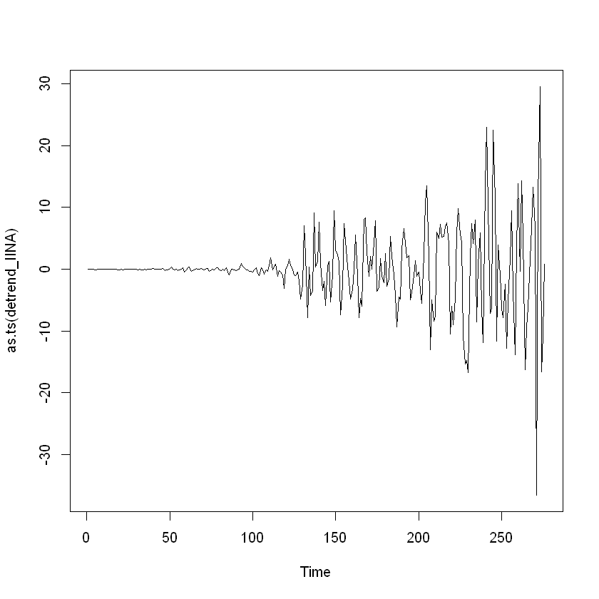

```r
detrend_IINA = IIN_f[,2] - trend_IIN3
plot(as.ts(detrend_IINA))
```

#### 6. Stationarity Test

To proceed further with ARIMA modeling, the nature of the data should be stationary. To check the stationarity of time series, Augmented Dicky-Fuller Test and Kwaitkoski and Phillips, Schmidt, and Shin Test has been used along with above graphical representation.

```r
adf = adf.test(detrend_IINA)
kpss = kpss.test(detrend_IINA)
adf
kpss
```

```
	Augmented Dickey-Fuller Test

data:  detrend_IINA
Dickey-Fuller = -7.6199, Lag order = 6, p-value = 0.01
alternative hypothesis: stationary
```

```
	KPSS Test for Level Stationarity

data:  detrend_IINA
KPSS Level = 0.0091441, Truncation lag parameter = 3, p-value = 0.1
```

Interpretation: Adf test reject null hypothesis and KPSS test accepts null hypothesis. This explains that the series is stationary.

#### 7. Checking Seasonality, Autoregressive Term (AR(p)), Moving Average (MA(q)), Integrated Term(d)):

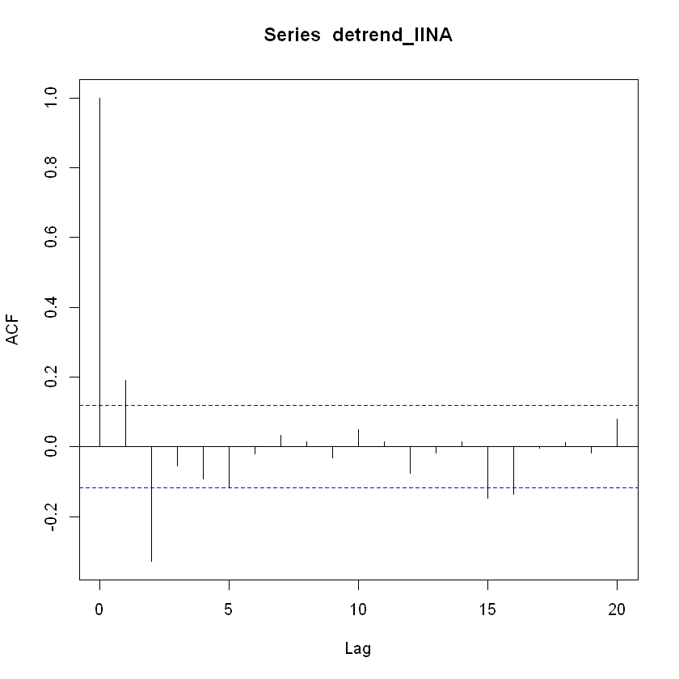

```r
acf(detrend_IINA, lag.max = 20)
```

[output not shown]

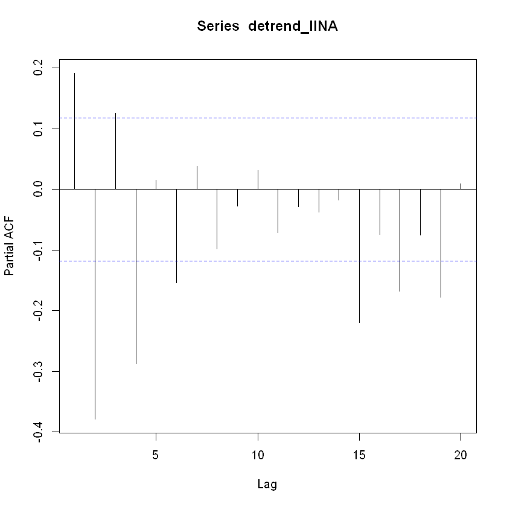

```r
pacf(detrend_IINA, lag.max = 20)
```

#### 8. Identifying and cross checking p,d,q of ARIMA using auto.arima

```r
auto.arima(detrend_IINA, trace= TRUE, ic ="aic")
```

```
 Fitting models using approximations to speed things up...

 ARIMA(2,0,2) with non-zero mean : Inf
 ARIMA(0,0,0) with non-zero mean : 1785.41
 ARIMA(1,0,0) with non-zero mean : 1778.109
 ARIMA(0,0,1) with non-zero mean : 1744.878
 ARIMA(0,0,0) with zero mean     : 1783.415
 ARIMA(1,0,1) with non-zero mean : 1729.878
 ARIMA(1,0,2) with non-zero mean : Inf
 ARIMA(1,0,1) with zero mean     : 1727.882
 ARIMA(0,0,1) with zero mean     : 1742.881
 ARIMA(2,0,1) with zero mean     : 1715.972
 ARIMA(2,0,0) with zero mean     : 1735.689
 ARIMA(2,0,2) with zero mean     : Inf
 ARIMA(1,0,0) with zero mean     : 1776.112
 ARIMA(3,0,2) with zero mean     : Inf
 ARIMA(2,0,1) with non-zero mean : 1717.964
 ARIMA(3,0,1) with zero mean     : 1718.719

 Now re-fitting the best model(s) without approximations...

 ARIMA(2,0,1) with zero mean     : 1714.639

 Best model: ARIMA(2,0,1) with zero mean
```

```
Series: detrend_IINA
ARIMA(2,0,1) with zero mean

Coefficients:
          ar1      ar2     ma1
      -0.2781  -0.2591  0.6816
s.e.   0.0788   0.0647  0.0629

sigma^2 estimated as 28.62:  log likelihood=-853.32
AIC=1714.64   AICc=1714.79   BIC=1729.12
```

Auto.arima is giving that arima(2,0,1)(p,d,q) with zero mean is appropriate model i.e, AR(p)=2 , MA(q)=1, d=0

Based on the Least AIC value criteria, it can be concluded that ARIMA(2,0,1) is our final model. Ie., ARMA(2,1).

```r
finalmodel = arima(detrend_IINA, order = c(2, 0, 1))
```

```r
### Results of the final model
summary(finalmodel)
```

```
Call:
arima(x = detrend_IINA, order = c(2, 0, 1))

Coefficients:
          ar1      ar2     ma1  intercept
      -0.2781  -0.2591  0.6816    -0.0305
s.e.   0.0788   0.0647  0.0629     0.3505

sigma^2 estimated as 28.31:  log likelihood = -853.32,  aic = 1716.63

Training set error measures:
                        ME     RMSE      MAE MPE MAPE      MASE        ACF1
Training set -1.727366e-05 5.320522 2.991371 Inf  Inf 0.7422254 -0.00502587
```